# Introduction to differential equations

2024

## Introduction

- *Since Newton, mankind has come to realise that the laws of physics are always expressed in the language of differential equations.* - Steven Strogatz
- “They are really freaking hard to solve!”
- https://www.youtube.com/watch?v=p_di4Zn4wz4
- https://www.youtube.com/watch?v=ly4S0oi3Yz8

## Algebraic Equations

- Solutions to algebraic equations are just numbers.
- Find an \(x\) that makes the following equation true.

\[ \begin{align*} x + 2 &= 4 \\ x &= 2 \end{align*} \]

## Algebraic Equations

- Algenraic equations can have multiple solutions.
- Each solution is still just a number.

\[ \begin{align*} x^2 + 3x + 2 &= 0 \\ (x + 1)(x + 2) &= 0 \\ x &= -1 \text{ or } x = -2 \end{align*} \]

## Differential Equations

- A differential equation is an equation that relates a function to its derivatives.
- You may see a few different notations for derivatives. E.g.,

\[ \begin{align*} \frac{dy}{dt} &= 2y \\ y^\prime(t) &= 2y(t) \\ f^\prime(t) &= 2f(t) \end{align*} \]

## Differential Equations

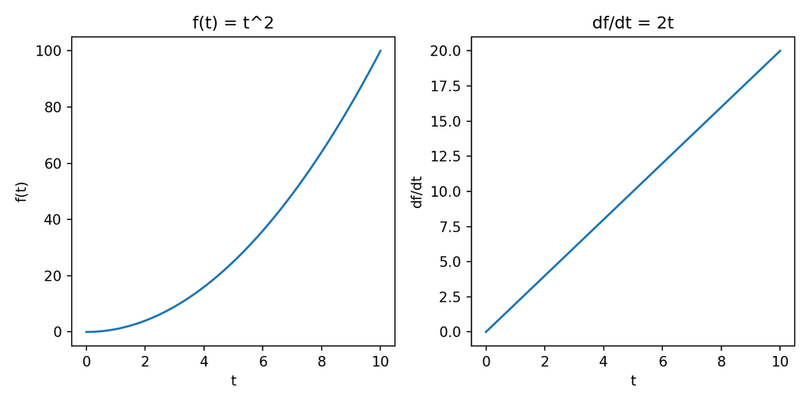

## Why are they important?

- Differential equations can be used to model the evolution of systems over time (e.g., \(\frac{d}{dt}\))
- It’s often easier to descirbe the rate of change of a system than to describe the present and future states of the system directly.

## Example: Response to a stimulus

- E.g., suppose you want to know how a population of neurons will fire in response to a brief current injection.
- Our intuition is that the rate of firing will increase during the injection and then decrease back to baseline.

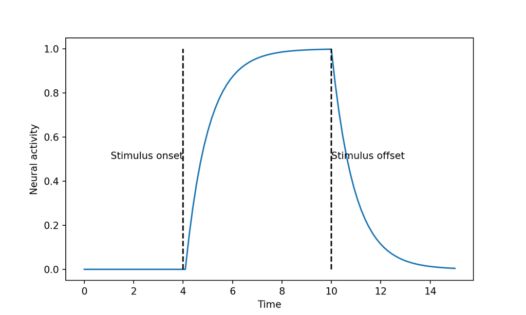

## A slightly more complex example

- The example of a single pulse of current injection may be too easy to imagine so the need for a differential equation may not be apparent.
- Here, we consider a more complex example of a neuron receiving a train of random current injections.

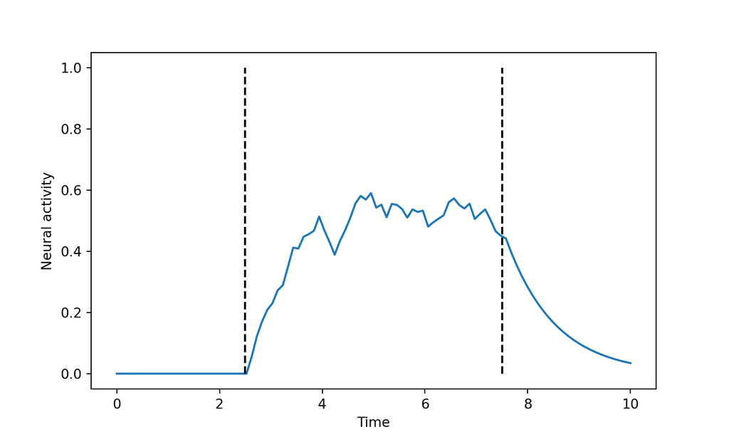

## Question 1

Given the differential equation \(\frac{dy}{dt} = ky\), where \(k > 0\), select the plot that represents a solution to this differential equation.

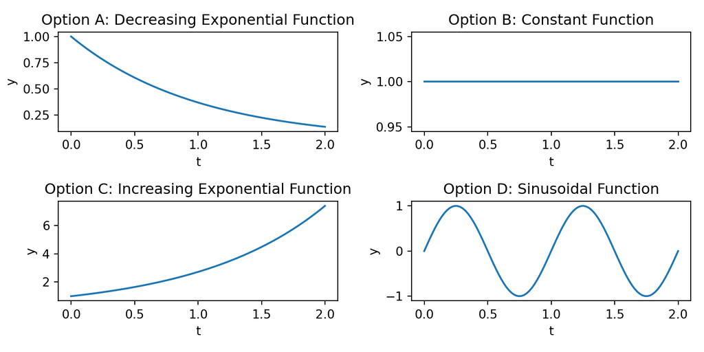

## Answer 1

**Answer**

- **Option C** shows an increasing exponential function, which is the **correct** representation of the solution to \(\frac{dy}{dt} = ky\) for \(k > 0\).

## Question 2

Given the differential equation \(\frac{d^2y}{dt^2} + y = 0\), which plot best represents a solution to this differential equation?

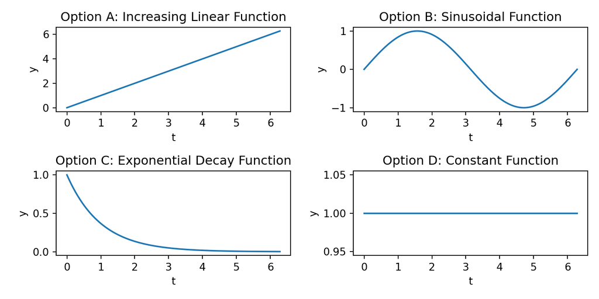

## Answer 2

**Answer**

The correct answer is **B) A sinusoidal function.** This is because the differential equation \(\frac{d^2y}{dt^2} + y = 0\) describes simple harmonic motion, whose solutions are sinusoidal functions.

## Question 3: Logistic Growth

Consider the logistic growth differential equation \(\frac{dy}{dt} = r y \left(1 - \frac{y}{K}\right)\), where \(r > 0\) and \(K > 0\). Which plot best represents a solution to this differential equation?

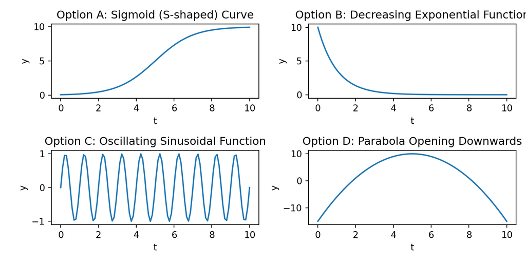

## Answer 3

**Answer**

**Correct Answer:** A) A sigmoid (S-shaped) curve approaching a horizontal asymptote.

## Question 4

Given the differential equation \(\frac{d^2y}{dt^2} + 2b\frac{dy}{dt} + y = 0\), where \(b > 0\) is a damping coefficient, select the plot that most likely represents a solution to this differential equation assuming the damping is under-critical.

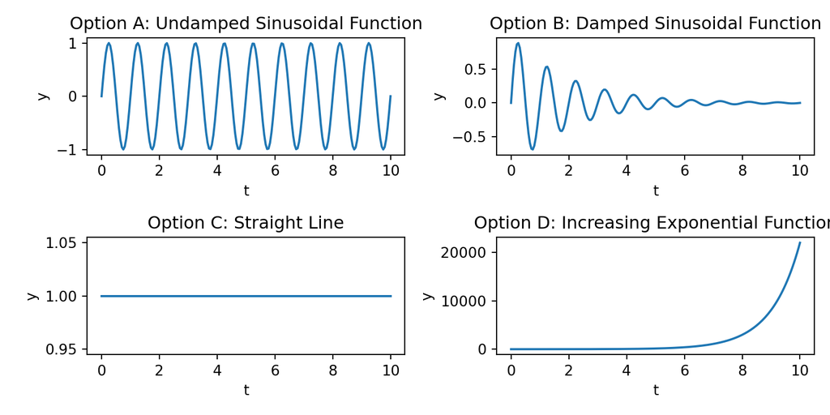

## Answer 4

**Answer**

**Correct Answer:** B) A sinusoidal function that gradually decreases in amplitude.